# Risk Factor Analysis

## Outcome Variable

**Outcome Variable:** stunted

## Predictor Variables

**Intervention Variable:** exclfeed36

**Adjustment Set:**

- arm
- sex
- brthmon
- W_mage
- meducyrs
- feducyrs
- hhwealth_quart
- hfoodsec
- W_mhtcm
- W_mwtkg
- W_mbmi
- vagbrth
- W_gagebrth
- W_birthwt
- W_birthlen
- W_nrooms
- W_nchldlt5
- month
- W_parity
- impfloor
- impsan
- safeh20
- delta_W_mage
- delta_meducyrs
- delta_feducyrs
- delta_hhwealth_quart
- delta_hfoodsec
- delta_W_mhtcm
- delta_W_mwtkg
- delta_W_mbmi
- delta_vagbrth
- delta_W_gagebrth
- delta_W_birthwt
- delta_W_birthlen
- delta_W_nrooms
- delta_W_nchldlt5
- delta_month
- delta_W_parity
- delta_impfloor
- delta_impsan
- delta_safeh20

## Stratifying Variables

The analysis was stratified on these variable(s):

- agecat
- studyid
- country

## Data Summary

| agecat | studyid | country | exclfeed36 | stunted | n_cell | n |
| --- | --- | --- | --- | --- | --- | --- |
| Birth | ki0047075b-MAL-ED | BANGLADESH | 1 | 0 | 28 | 221 |
| Birth | ki0047075b-MAL-ED | BANGLADESH | 1 | 1 | 4 | 221 |
| Birth | ki0047075b-MAL-ED | BANGLADESH | 0 | 0 | 153 | 221 |
| Birth | ki0047075b-MAL-ED | BANGLADESH | 0 | 1 | 36 | 221 |
| Birth | ki0047075b-MAL-ED | BRAZIL | 1 | 0 | 3 | 65 |
| Birth | ki0047075b-MAL-ED | BRAZIL | 1 | 1 | 2 | 65 |
| Birth | ki0047075b-MAL-ED | BRAZIL | 0 | 0 | 53 | 65 |
| Birth | ki0047075b-MAL-ED | BRAZIL | 0 | 1 | 7 | 65 |
| Birth | ki0047075b-MAL-ED | INDIA | 1 | 0 | 0 | 42 |
| Birth | ki0047075b-MAL-ED | INDIA | 1 | 1 | 1 | 42 |
| Birth | ki0047075b-MAL-ED | INDIA | 0 | 0 | 33 | 42 |
| Birth | ki0047075b-MAL-ED | INDIA | 0 | 1 | 8 | 42 |
| Birth | ki0047075b-MAL-ED | NEPAL | 1 | 0 | 0 | 26 |
| Birth | ki0047075b-MAL-ED | NEPAL | 1 | 1 | 0 | 26 |
| Birth | ki0047075b-MAL-ED | NEPAL | 0 | 0 | 24 | 26 |
| Birth | ki0047075b-MAL-ED | NEPAL | 0 | 1 | 2 | 26 |
| Birth | ki0047075b-MAL-ED | PERU | 1 | 0 | 5 | 223 |
| Birth | ki0047075b-MAL-ED | PERU | 1 | 1 | 0 | 223 |
| Birth | ki0047075b-MAL-ED | PERU | 0 | 0 | 192 | 223 |
| Birth | ki0047075b-MAL-ED | PERU | 0 | 1 | 26 | 223 |
| Birth | ki0047075b-MAL-ED | SOUTH AFRICA | 1 | 0 | 1 | 105 |
| Birth | ki0047075b-MAL-ED | SOUTH AFRICA | 1 | 1 | 0 | 105 |
| Birth | ki0047075b-MAL-ED | SOUTH AFRICA | 0 | 0 | 95 | 105 |
| Birth | ki0047075b-MAL-ED | SOUTH AFRICA | 0 | 1 | 9 | 105 |
| Birth | ki0047075b-MAL-ED | TANZANIA, UNITED REPUBLIC OF | 1 | 0 | 0 | 119 |
| Birth | ki0047075b-MAL-ED | TANZANIA, UNITED REPUBLIC OF | 1 | 1 | 0 | 119 |
| Birth | ki0047075b-MAL-ED | TANZANIA, UNITED REPUBLIC OF | 0 | 0 | 98 | 119 |
| Birth | ki0047075b-MAL-ED | TANZANIA, UNITED REPUBLIC OF | 0 | 1 | 21 | 119 |
| Birth | ki1000108-CMC-V-BCS-2002 | INDIA | 1 | 0 | 3 | 3 |
| Birth | ki1000108-CMC-V-BCS-2002 | INDIA | 1 | 1 | 0 | 3 |

[output cut: 162 more lines]

The following strata were considered:

- agecat: 24 months, studyid: ki0047075b-MAL-ED, country: BANGLADESH
- agecat: 24 months, studyid: ki0047075b-MAL-ED, country: BRAZIL
- agecat: 24 months, studyid: ki0047075b-MAL-ED, country: INDIA
- agecat: 24 months, studyid: ki0047075b-MAL-ED, country: NEPAL
- agecat: 24 months, studyid: ki0047075b-MAL-ED, country: PERU
- agecat: 24 months, studyid: ki0047075b-MAL-ED, country: SOUTH AFRICA
- agecat: 24 months, studyid: ki0047075b-MAL-ED, country: TANZANIA, UNITED REPUBLIC OF
- agecat: 24 months, studyid: ki1000108-CMC-V-BCS-2002, country: INDIA
- agecat: 24 months, studyid: ki1000108-IRC, country: INDIA
- agecat: 24 months, studyid: ki1000109-EE, country: PAKISTAN
- agecat: 24 months, studyid: ki1017093b-PROVIDE, country: BANGLADESH
- agecat: 24 months, studyid: ki1101329-Keneba, country: GAMBIA
- agecat: 24 months, studyid: ki1113344-GMS-Nepal, country: NEPAL
- agecat: 24 months, studyid: ki1148112-LCNI-5, country: MALAWI
- agecat: 24 months, studyid: kiGH5241-JiVitA-3, country: BANGLADESH
- agecat: 24 months, studyid: kiGH5241-JiVitA-4, country: BANGLADESH
- agecat: 6 months, studyid: ki0047075b-MAL-ED, country: BANGLADESH
- agecat: 6 months, studyid: ki0047075b-MAL-ED, country: BRAZIL
- agecat: 6 months, studyid: ki0047075b-MAL-ED, country: INDIA
- agecat: 6 months, studyid: ki0047075b-MAL-ED, country: NEPAL
- agecat: 6 months, studyid: ki0047075b-MAL-ED, country: PERU
- agecat: 6 months, studyid: ki0047075b-MAL-ED, country: SOUTH AFRICA
- agecat: 6 months, studyid: ki0047075b-MAL-ED, country: TANZANIA, UNITED REPUBLIC OF
- agecat: 6 months, studyid: ki1000108-CMC-V-BCS-2002, country: INDIA
- agecat: 6 months, studyid: ki1000108-IRC, country: INDIA
- agecat: 6 months, studyid: ki1000109-EE, country: PAKISTAN
- agecat: 6 months, studyid: ki1000304b-SAS-FoodSuppl, country: INDIA
- agecat: 6 months, studyid: ki1017093b-PROVIDE, country: BANGLADESH
- agecat: 6 months, studyid: ki1101329-Keneba, country: GAMBIA
- agecat: 6 months, studyid: ki1113344-GMS-Nepal, country: NEPAL
- agecat: 6 months, studyid: ki1148112-LCNI-5, country: MALAWI
- agecat: 6 months, studyid: kiGH5241-JiVitA-3, country: BANGLADESH
- agecat: 6 months, studyid: kiGH5241-JiVitA-4, country: BANGLADESH
- agecat: Birth, studyid: ki0047075b-MAL-ED, country: BANGLADESH
- agecat: Birth, studyid: ki0047075b-MAL-ED, country: BRAZIL
- agecat: Birth, studyid: ki0047075b-MAL-ED, country: INDIA
- agecat: Birth, studyid: ki0047075b-MAL-ED, country: NEPAL
- agecat: Birth, studyid: ki0047075b-MAL-ED, country: PERU
- agecat: Birth, studyid: ki0047075b-MAL-ED, country: SOUTH AFRICA
- agecat: Birth, studyid: ki0047075b-MAL-ED, country: TANZANIA, UNITED REPUBLIC OF
- agecat: Birth, studyid: ki1000108-CMC-V-BCS-2002, country: INDIA
- agecat: Birth, studyid: ki1000108-IRC, country: INDIA
- agecat: Birth, studyid: ki1000109-EE, country: PAKISTAN
- agecat: Birth, studyid: ki1017093b-PROVIDE, country: BANGLADESH
- agecat: Birth, studyid: ki1101329-Keneba, country: GAMBIA
- agecat: Birth, studyid: ki1113344-GMS-Nepal, country: NEPAL
- agecat: Birth, studyid: kiGH5241-JiVitA-3, country: BANGLADESH
- agecat: Birth, studyid: kiGH5241-JiVitA-4, country: BANGLADESH

### Dropped Strata

Some strata were dropped due to rare outcomes:

- agecat: Birth, studyid: ki0047075b-MAL-ED, country: BANGLADESH
- agecat: Birth, studyid: ki0047075b-MAL-ED, country: BRAZIL
- agecat: Birth, studyid: ki0047075b-MAL-ED, country: INDIA
- agecat: Birth, studyid: ki0047075b-MAL-ED, country: NEPAL
- agecat: Birth, studyid: ki0047075b-MAL-ED, country: PERU
- agecat: Birth, studyid: ki0047075b-MAL-ED, country: SOUTH AFRICA
- agecat: Birth, studyid: ki0047075b-MAL-ED, country: TANZANIA, UNITED REPUBLIC OF
- agecat: Birth, studyid: ki1000108-CMC-V-BCS-2002, country: INDIA
- agecat: Birth, studyid: ki1000108-IRC, country: INDIA
- agecat: Birth, studyid: ki1000109-EE, country: PAKISTAN
- agecat: 6 months, studyid: ki0047075b-MAL-ED, country: BRAZIL
- agecat: 6 months, studyid: ki0047075b-MAL-ED, country: INDIA
- agecat: 6 months, studyid: ki0047075b-MAL-ED, country: NEPAL
- agecat: 6 months, studyid: ki0047075b-MAL-ED, country: PERU
- agecat: 6 months, studyid: ki0047075b-MAL-ED, country: SOUTH AFRICA
- agecat: 6 months, studyid: ki0047075b-MAL-ED, country: TANZANIA, UNITED REPUBLIC OF
- agecat: 6 months, studyid: ki1000108-CMC-V-BCS-2002, country: INDIA
- agecat: 6 months, studyid: ki1000108-IRC, country: INDIA
- agecat: 6 months, studyid: ki1000109-EE, country: PAKISTAN
- agecat: 6 months, studyid: ki1000304b-SAS-FoodSuppl, country: INDIA
- agecat: 24 months, studyid: ki0047075b-MAL-ED, country: BRAZIL
- agecat: 24 months, studyid: ki0047075b-MAL-ED, country: INDIA
- agecat: 24 months, studyid: ki0047075b-MAL-ED, country: NEPAL
- agecat: 24 months, studyid: ki0047075b-MAL-ED, country: PERU
- agecat: 24 months, studyid: ki0047075b-MAL-ED, country: SOUTH AFRICA
- agecat: 24 months, studyid: ki0047075b-MAL-ED, country: TANZANIA, UNITED REPUBLIC OF
- agecat: 24 months, studyid: ki1000108-CMC-V-BCS-2002, country: INDIA
- agecat: 24 months, studyid: ki1000108-IRC, country: INDIA
- agecat: 24 months, studyid: ki1000109-EE, country: PAKISTAN

## Methods Detail

We’re interested in the causal parameters $E[Y_a]$ for all values of $a \in \mathcal{A}$. These parameters represent the mean outcome if, possibly contrary to fact, we intervened to set all units to have $A=a$. Under the randomization and positivity assumptions, these are identified by the statistical parameters $\psi_a=E_W[E_{Y|A,W}(Y|A=a,W)]$. In addition, we’re interested in the mean of $Y$, $E[Y]$ under no intervention (the observed mean). We will estimate these parameters by using SuperLearner to fit the relevant likelihood factors – $E_{Y|A,W}(Y|A=a,W)$ and $p(A=a|W)$, and then updating our likelihood fit using a joint TMLE.

For unadjusted analyses ($W=\{\}$), initial likelihoods were estimated using Lrnr_glm to estimate the simple $E(Y|A)$ and Lrnr_mean to estimate $p(A)$. For adjusted analyses, a small library containing Lrnr_glmnet, Lrnr_xgboost, and Lrnr_mean was used.

Having estimated these parameters, we will then use the delta method to estimate relative risks and attributable risks relative to a prespecified baseline level of $A$.

# Results Detail

## Results Plots

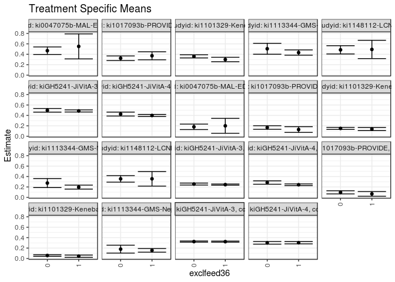

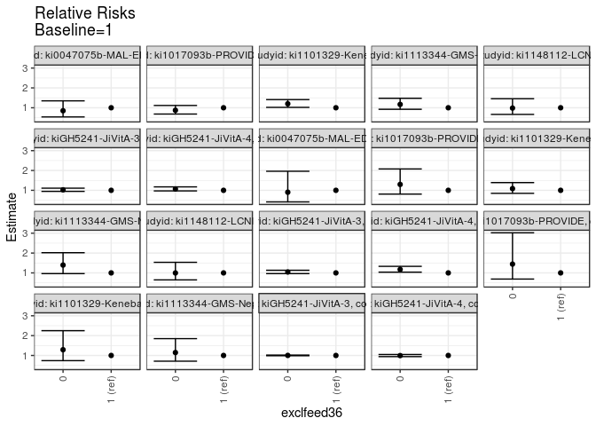

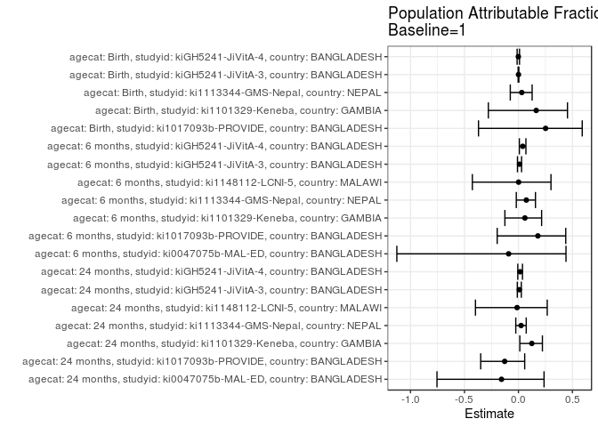

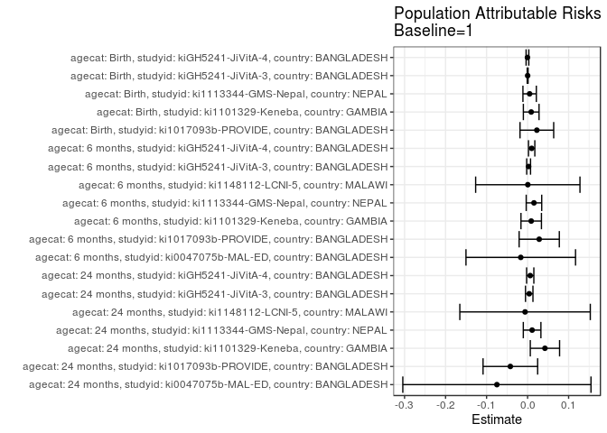

## Results Table

### Parameter: TSM

| agecat | studyid | country | intervention_level | baseline_level | estimate | ci_lower | ci_upper |
| --- | --- | --- | --- | --- | --- | --- | --- |
| Birth | ki1017093b-PROVIDE | BANGLADESH | 1 | NA | 0.0672269 | 0.0221890 | 0.1122648 |
| Birth | ki1017093b-PROVIDE | BANGLADESH | 0 | NA | 0.0970350 | 0.0668838 | 0.1271862 |
| Birth | ki1101329-Keneba | GAMBIA | 1 | NA | 0.0446693 | 0.0229115 | 0.0664271 |
| Birth | ki1101329-Keneba | GAMBIA | 0 | NA | 0.0576064 | 0.0422057 | 0.0730070 |
| Birth | ki1113344-GMS-Nepal | NEPAL | 1 | NA | 0.1566165 | 0.1218226 | 0.1914103 |
| Birth | ki1113344-GMS-Nepal | NEPAL | 0 | NA | 0.1796868 | 0.1041165 | 0.2552571 |
| Birth | kiGH5241-JiVitA-3 | BANGLADESH | 1 | NA | 0.3233379 | 0.3129475 | 0.3337283 |
| Birth | kiGH5241-JiVitA-3 | BANGLADESH | 0 | NA | 0.3242368 | 0.3132560 | 0.3352176 |
| Birth | kiGH5241-JiVitA-4 | BANGLADESH | 1 | NA | 0.3026865 | 0.2806212 | 0.3247518 |
| Birth | kiGH5241-JiVitA-4 | BANGLADESH | 0 | NA | 0.3006977 | 0.2757306 | 0.3256647 |
| 6 months | ki0047075b-MAL-ED | BANGLADESH | 1 | NA | 0.2000000 | 0.0565653 | 0.3434347 |
| 6 months | ki0047075b-MAL-ED | BANGLADESH | 0 | NA | 0.1809524 | 0.1287751 | 0.2331297 |
| 6 months | ki1017093b-PROVIDE | BANGLADESH | 1 | NA | 0.1291812 | 0.0742354 | 0.1841270 |
| 6 months | ki1017093b-PROVIDE | BANGLADESH | 0 | NA | 0.1676167 | 0.1335270 | 0.2017064 |
| 6 months | ki1101329-Keneba | GAMBIA | 1 | NA | 0.1386663 | 0.1090027 | 0.1683300 |
| 6 months | ki1101329-Keneba | GAMBIA | 0 | NA | 0.1507041 | 0.1313648 | 0.1700433 |
| 6 months | ki1113344-GMS-Nepal | NEPAL | 1 | NA | 0.1970003 | 0.1589704 | 0.2350302 |
| 6 months | ki1113344-GMS-Nepal | NEPAL | 0 | NA | 0.2746743 | 0.1882608 | 0.3610877 |
| 6 months | ki1148112-LCNI-5 | MALAWI | 1 | NA | 0.3560788 | 0.2167258 | 0.4954318 |
| 6 months | ki1148112-LCNI-5 | MALAWI | 0 | NA | 0.3551064 | 0.2923292 | 0.4178836 |
| 6 months | kiGH5241-JiVitA-3 | BANGLADESH | 1 | NA | 0.2446961 | 0.2331967 | 0.2561955 |
| 6 months | kiGH5241-JiVitA-3 | BANGLADESH | 0 | NA | 0.2555941 | 0.2366101 | 0.2745780 |
| 6 months | kiGH5241-JiVitA-4 | BANGLADESH | 1 | NA | 0.2426583 | 0.2266903 | 0.2586263 |
| 6 months | kiGH5241-JiVitA-4 | BANGLADESH | 0 | NA | 0.2850356 | 0.2524696 | 0.3176017 |
| 24 months | ki0047075b-MAL-ED | BANGLADESH | 1 | NA | 0.5512419 | 0.3118327 | 0.7906510 |
| 24 months | ki0047075b-MAL-ED | BANGLADESH | 0 | NA | 0.4688205 | 0.3967350 | 0.5409060 |
| 24 months | ki1017093b-PROVIDE | BANGLADESH | 1 | NA | 0.3713369 | 0.2945906 | 0.4480831 |
| 24 months | ki1017093b-PROVIDE | BANGLADESH | 0 | NA | 0.3242411 | 0.2804094 | 0.3680728 |
| 24 months | ki1101329-Keneba | GAMBIA | 1 | NA | 0.2998996 | 0.2571577 | 0.3426415 |
| 24 months | ki1101329-Keneba | GAMBIA | 0 | NA | 0.3599002 | 0.3300883 | 0.3897121 |
| 24 months | ki1113344-GMS-Nepal | NEPAL | 1 | NA | 0.4329321 | 0.3822637 | 0.4836005 |
| 24 months | ki1113344-GMS-Nepal | NEPAL | 0 | NA | 0.5057488 | 0.4007389 | 0.6107586 |
| 24 months | ki1148112-LCNI-5 | MALAWI | 1 | NA | 0.4929371 | 0.3177283 | 0.6681459 |
| 24 months | ki1148112-LCNI-5 | MALAWI | 0 | NA | 0.4852648 | 0.4060246 | 0.5645050 |
| 24 months | kiGH5241-JiVitA-3 | BANGLADESH | 1 | NA | 0.4856441 | 0.4655114 | 0.5057767 |
| 24 months | kiGH5241-JiVitA-3 | BANGLADESH | 0 | NA | 0.4978178 | 0.4626756 | 0.5329600 |
| 24 months | kiGH5241-JiVitA-4 | BANGLADESH | 1 | NA | 0.3988733 | 0.3786170 | 0.4191296 |
| 24 months | kiGH5241-JiVitA-4 | BANGLADESH | 0 | NA | 0.4258012 | 0.3881747 | 0.4634278 |

### Parameter: E(Y)

| agecat | studyid | country | intervention_level | baseline_level | estimate | ci_lower | ci_upper |
| --- | --- | --- | --- | --- | --- | --- | --- |
| Birth | ki1017093b-PROVIDE | BANGLADESH | NA | NA | 0.0897959 | 0.0644568 | 0.1151350 |
| Birth | ki1101329-Keneba | GAMBIA | NA | NA | 0.0534717 | 0.0410100 | 0.0659333 |
| Birth | ki1113344-GMS-Nepal | NEPAL | NA | NA | 0.1615970 | 0.1301114 | 0.1930825 |
| Birth | kiGH5241-JiVitA-3 | BANGLADESH | NA | NA | 0.3234716 | 0.3131402 | 0.3338029 |
| Birth | kiGH5241-JiVitA-4 | BANGLADESH | NA | NA | 0.3023441 | 0.2806174 | 0.3240708 |
| 6 months | ki0047075b-MAL-ED | BANGLADESH | NA | NA | 0.1833333 | 0.1342773 | 0.2323893 |
| 6 months | ki1017093b-PROVIDE | BANGLADESH | NA | NA | 0.1575456 | 0.1284434 | 0.1866478 |
| 6 months | ki1101329-Keneba | GAMBIA | NA | NA | 0.1474860 | 0.1310548 | 0.1639172 |
| 6 months | ki1113344-GMS-Nepal | NEPAL | NA | NA | 0.2125237 | 0.1775632 | 0.2474842 |
| 6 months | ki1148112-LCNI-5 | MALAWI | NA | NA | 0.3566176 | 0.2995882 | 0.4136471 |
| 6 months | kiGH5241-JiVitA-3 | BANGLADESH | NA | NA | 0.2471936 | 0.2366536 | 0.2577336 |
| 6 months | kiGH5241-JiVitA-4 | BANGLADESH | NA | NA | 0.2525687 | 0.2374550 | 0.2676823 |
| 24 months | ki0047075b-MAL-ED | BANGLADESH | NA | NA | 0.4764151 | 0.4090254 | 0.5438047 |
| 24 months | ki1017093b-PROVIDE | BANGLADESH | NA | NA | 0.3292894 | 0.2909105 | 0.3676684 |
| 24 months | ki1101329-Keneba | GAMBIA | NA | NA | 0.3421808 | 0.3172662 | 0.3670954 |
| 24 months | ki1113344-GMS-Nepal | NEPAL | NA | NA | 0.4439462 | 0.3977834 | 0.4901089 |
| 24 months | ki1148112-LCNI-5 | MALAWI | NA | NA | 0.4867725 | 0.4153250 | 0.5582200 |
| 24 months | kiGH5241-JiVitA-3 | BANGLADESH | NA | NA | 0.4896170 | 0.4715168 | 0.5077172 |
| 24 months | kiGH5241-JiVitA-4 | BANGLADESH | NA | NA | 0.4052853 | 0.3865623 | 0.4240082 |

### Parameter: RR

| agecat | studyid | country | intervention_level | baseline_level | estimate | ci_lower | ci_upper |
| --- | --- | --- | --- | --- | --- | --- | --- |
| Birth | ki1017093b-PROVIDE | BANGLADESH | 1 | 1 | 1.0000000 | 1.0000000 | 1.000000 |
| Birth | ki1017093b-PROVIDE | BANGLADESH | 0 | 1 | 1.4433962 | 0.6897053 | 3.020700 |
| Birth | ki1101329-Keneba | GAMBIA | 1 | 1 | 1.0000000 | 1.0000000 | 1.000000 |
| Birth | ki1101329-Keneba | GAMBIA | 0 | 1 | 1.2896195 | 0.7396488 | 2.248524 |
| Birth | ki1113344-GMS-Nepal | NEPAL | 1 | 1 | 1.0000000 | 1.0000000 | 1.000000 |
| Birth | ki1113344-GMS-Nepal | NEPAL | 0 | 1 | 1.1473045 | 0.7124418 | 1.847600 |
| Birth | kiGH5241-JiVitA-3 | BANGLADESH | 1 | 1 | 1.0000000 | 1.0000000 | 1.000000 |
| Birth | kiGH5241-JiVitA-3 | BANGLADESH | 0 | 1 | 1.0027802 | 0.9878914 | 1.017893 |
| Birth | kiGH5241-JiVitA-4 | BANGLADESH | 1 | 1 | 1.0000000 | 1.0000000 | 1.000000 |
| Birth | kiGH5241-JiVitA-4 | BANGLADESH | 0 | 1 | 0.9934293 | 0.9413508 | 1.048389 |
| 6 months | ki0047075b-MAL-ED | BANGLADESH | 1 | 1 | 1.0000000 | 1.0000000 | 1.000000 |
| 6 months | ki0047075b-MAL-ED | BANGLADESH | 0 | 1 | 0.9047619 | 0.4176743 | 1.959886 |
| 6 months | ki1017093b-PROVIDE | BANGLADESH | 1 | 1 | 1.0000000 | 1.0000000 | 1.000000 |
| 6 months | ki1017093b-PROVIDE | BANGLADESH | 0 | 1 | 1.2975318 | 0.8106252 | 2.076901 |
| 6 months | ki1101329-Keneba | GAMBIA | 1 | 1 | 1.0000000 | 1.0000000 | 1.000000 |
| 6 months | ki1101329-Keneba | GAMBIA | 0 | 1 | 1.0868108 | 0.8497683 | 1.389976 |
| 6 months | ki1113344-GMS-Nepal | NEPAL | 1 | 1 | 1.0000000 | 1.0000000 | 1.000000 |
| 6 months | ki1113344-GMS-Nepal | NEPAL | 0 | 1 | 1.3942835 | 0.9636579 | 2.017341 |
| 6 months | ki1148112-LCNI-5 | MALAWI | 1 | 1 | 1.0000000 | 1.0000000 | 1.000000 |
| 6 months | ki1148112-LCNI-5 | MALAWI | 0 | 1 | 0.9972690 | 0.6486364 | 1.533287 |
| 6 months | kiGH5241-JiVitA-3 | BANGLADESH | 1 | 1 | 1.0000000 | 1.0000000 | 1.000000 |
| 6 months | kiGH5241-JiVitA-3 | BANGLADESH | 0 | 1 | 1.0445367 | 0.9637631 | 1.132080 |
| 6 months | kiGH5241-JiVitA-4 | BANGLADESH | 1 | 1 | 1.0000000 | 1.0000000 | 1.000000 |
| 6 months | kiGH5241-JiVitA-4 | BANGLADESH | 0 | 1 | 1.1746379 | 1.0368775 | 1.330701 |
| 24 months | ki0047075b-MAL-ED | BANGLADESH | 1 | 1 | 1.0000000 | 1.0000000 | 1.000000 |
| 24 months | ki0047075b-MAL-ED | BANGLADESH | 0 | 1 | 0.8504806 | 0.5364929 | 1.348232 |
| 24 months | ki1017093b-PROVIDE | BANGLADESH | 1 | 1 | 1.0000000 | 1.0000000 | 1.000000 |
| 24 months | ki1017093b-PROVIDE | BANGLADESH | 0 | 1 | 0.8731723 | 0.6837334 | 1.115098 |
| 24 months | ki1101329-Keneba | GAMBIA | 1 | 1 | 1.0000000 | 1.0000000 | 1.000000 |
| 24 months | ki1101329-Keneba | GAMBIA | 0 | 1 | 1.2000689 | 1.0203185 | 1.411486 |
| 24 months | ki1113344-GMS-Nepal | NEPAL | 1 | 1 | 1.0000000 | 1.0000000 | 1.000000 |
| 24 months | ki1113344-GMS-Nepal | NEPAL | 0 | 1 | 1.1681941 | 0.9234842 | 1.477749 |
| 24 months | ki1148112-LCNI-5 | MALAWI | 1 | 1 | 1.0000000 | 1.0000000 | 1.000000 |
| 24 months | ki1148112-LCNI-5 | MALAWI | 0 | 1 | 0.9844355 | 0.6656915 | 1.455799 |
| 24 months | kiGH5241-JiVitA-3 | BANGLADESH | 1 | 1 | 1.0000000 | 1.0000000 | 1.000000 |
| 24 months | kiGH5241-JiVitA-3 | BANGLADESH | 0 | 1 | 1.0250672 | 0.9476086 | 1.108857 |
| 24 months | kiGH5241-JiVitA-4 | BANGLADESH | 1 | 1 | 1.0000000 | 1.0000000 | 1.000000 |
| 24 months | kiGH5241-JiVitA-4 | BANGLADESH | 0 | 1 | 1.0675101 | 0.9707616 | 1.173901 |

### Parameter: PAR

| agecat | studyid | country | intervention_level | baseline_level | estimate | ci_lower | ci_upper |
| --- | --- | --- | --- | --- | --- | --- | --- |
| Birth | ki1017093b-PROVIDE | BANGLADESH | 1 | NA | 0.0225690 | -0.0184828 | 0.0636209 |
| Birth | ki1101329-Keneba | GAMBIA | 1 | NA | 0.0088024 | -0.0103091 | 0.0279139 |
| Birth | ki1113344-GMS-Nepal | NEPAL | 1 | NA | 0.0049805 | -0.0113660 | 0.0213270 |
| Birth | kiGH5241-JiVitA-3 | BANGLADESH | 1 | NA | 0.0001337 | -0.0009524 | 0.0012199 |
| Birth | kiGH5241-JiVitA-4 | BANGLADESH | 1 | NA | -0.0003425 | -0.0037033 | 0.0030184 |
| 6 months | ki0047075b-MAL-ED | BANGLADESH | 1 | NA | -0.0166667 | -0.1502205 | 0.1168871 |
| 6 months | ki1017093b-PROVIDE | BANGLADESH | 1 | NA | 0.0283644 | -0.0206332 | 0.0773620 |
| 6 months | ki1101329-Keneba | GAMBIA | 1 | NA | 0.0088197 | -0.0161375 | 0.0337769 |
| 6 months | ki1113344-GMS-Nepal | NEPAL | 1 | NA | 0.0155234 | -0.0033918 | 0.0344386 |
| 6 months | ki1148112-LCNI-5 | MALAWI | 1 | NA | 0.0005388 | -0.1266337 | 0.1277114 |
| 6 months | kiGH5241-JiVitA-3 | BANGLADESH | 1 | NA | 0.0024975 | -0.0021967 | 0.0071917 |
| 6 months | kiGH5241-JiVitA-4 | BANGLADESH | 1 | NA | 0.0099104 | 0.0021892 | 0.0176316 |
| 24 months | ki0047075b-MAL-ED | BANGLADESH | 1 | NA | -0.0748268 | -0.3042256 | 0.1545721 |
| 24 months | ki1017093b-PROVIDE | BANGLADESH | 1 | NA | -0.0420474 | -0.1086034 | 0.0245085 |
| 24 months | ki1101329-Keneba | GAMBIA | 1 | NA | 0.0422812 | 0.0065757 | 0.0779867 |
| 24 months | ki1113344-GMS-Nepal | NEPAL | 1 | NA | 0.0110141 | -0.0104481 | 0.0324762 |
| 24 months | ki1148112-LCNI-5 | MALAWI | 1 | NA | -0.0061646 | -0.1652234 | 0.1528942 |
| 24 months | kiGH5241-JiVitA-3 | BANGLADESH | 1 | NA | 0.0039729 | -0.0051117 | 0.0130575 |
| 24 months | kiGH5241-JiVitA-4 | BANGLADESH | 1 | NA | 0.0064120 | -0.0024174 | 0.0152413 |

### Parameter: PAF

| agecat | studyid | country | intervention_level | baseline_level | estimate | ci_lower | ci_upper |
| --- | --- | --- | --- | --- | --- | --- | --- |
| Birth | ki1017093b-PROVIDE | BANGLADESH | 1 | NA | 0.2513369 | -0.3701009 | 0.5909086 |
| Birth | ki1101329-Keneba | GAMBIA | 1 | NA | 0.1646178 | -0.2787621 | 0.4542664 |
| Birth | ki1113344-GMS-Nepal | NEPAL | 1 | NA | 0.0308204 | -0.0756905 | 0.1267850 |
| Birth | kiGH5241-JiVitA-3 | BANGLADESH | 1 | NA | 0.0004134 | -0.0029501 | 0.0037656 |
| Birth | kiGH5241-JiVitA-4 | BANGLADESH | 1 | NA | -0.0011327 | -0.0123090 | 0.0099202 |
| 6 months | ki0047075b-MAL-ED | BANGLADESH | 1 | NA | -0.0909091 | -1.1267403 | 0.4404194 |
| 6 months | ki1017093b-PROVIDE | BANGLADESH | 1 | NA | 0.1800393 | -0.1968702 | 0.4382552 |
| 6 months | ki1101329-Keneba | GAMBIA | 1 | NA | 0.0598001 | -0.1256330 | 0.2146856 |
| 6 months | ki1113344-GMS-Nepal | NEPAL | 1 | NA | 0.0730432 | -0.0199268 | 0.1575386 |
| 6 months | ki1148112-LCNI-5 | MALAWI | 1 | NA | 0.0015110 | -0.4270868 | 0.3013877 |
| 6 months | kiGH5241-JiVitA-3 | BANGLADESH | 1 | NA | 0.0101036 | -0.0090708 | 0.0289136 |
| 6 months | kiGH5241-JiVitA-4 | BANGLADESH | 1 | NA | 0.0392384 | 0.0084276 | 0.0690919 |
| 24 months | ki0047075b-MAL-ED | BANGLADESH | 1 | NA | -0.1570621 | -0.7548476 | 0.2370889 |
| 24 months | ki1017093b-PROVIDE | BANGLADESH | 1 | NA | -0.1276915 | -0.3497560 | 0.0578386 |
| 24 months | ki1101329-Keneba | GAMBIA | 1 | NA | 0.1235639 | 0.0127060 | 0.2219741 |
| 24 months | ki1113344-GMS-Nepal | NEPAL | 1 | NA | 0.0248095 | -0.0247919 | 0.0720101 |
| 24 months | ki1148112-LCNI-5 | MALAWI | 1 | NA | -0.0126642 | -0.3982786 | 0.2666062 |
| 24 months | kiGH5241-JiVitA-3 | BANGLADESH | 1 | NA | 0.0081143 | -0.0106127 | 0.0264944 |
| 24 months | kiGH5241-JiVitA-4 | BANGLADESH | 1 | NA | 0.0158209 | -0.0061789 | 0.0373397 |